# Cell-Cell interaction: NicheNet

Università degli Studi di Milano | Single cell analysis boot camp

2023-09-14

# Prepare NicheNet analysis

### Load Packages:

```r
library(nichenetr)
library(Seurat)
library(tidyverse)
library(openxlsx)
library(circlize)
```

### Read and visualize the Seurat objects:

#### MAIT cells

```r
MAIT = readRDS("/Users/LabMavilio/Desktop/CDP_MAIT/Mait.RDS")
head(MAIT@meta.data)
```

```
##                               time patient_id seurat_cluster
## AAACGGGAGAGTCTGG-1-VCOV_01_P1   P0         01              2
## AAAGTAGTCATCGATG-1-VCOV_01_P1   P0         01              0
## AAAGTAGTCTACCAGA-1-VCOV_01_P1   P0         01              3
## AACACGTAGTTACGGG-1-VCOV_01_P1   P0         01              0
## AACACGTCAGCATACT-1-VCOV_01_P1   P0         01              0
## AACGTTGTCTTGCAAG-1-VCOV_01_P1   P0         01              2
```

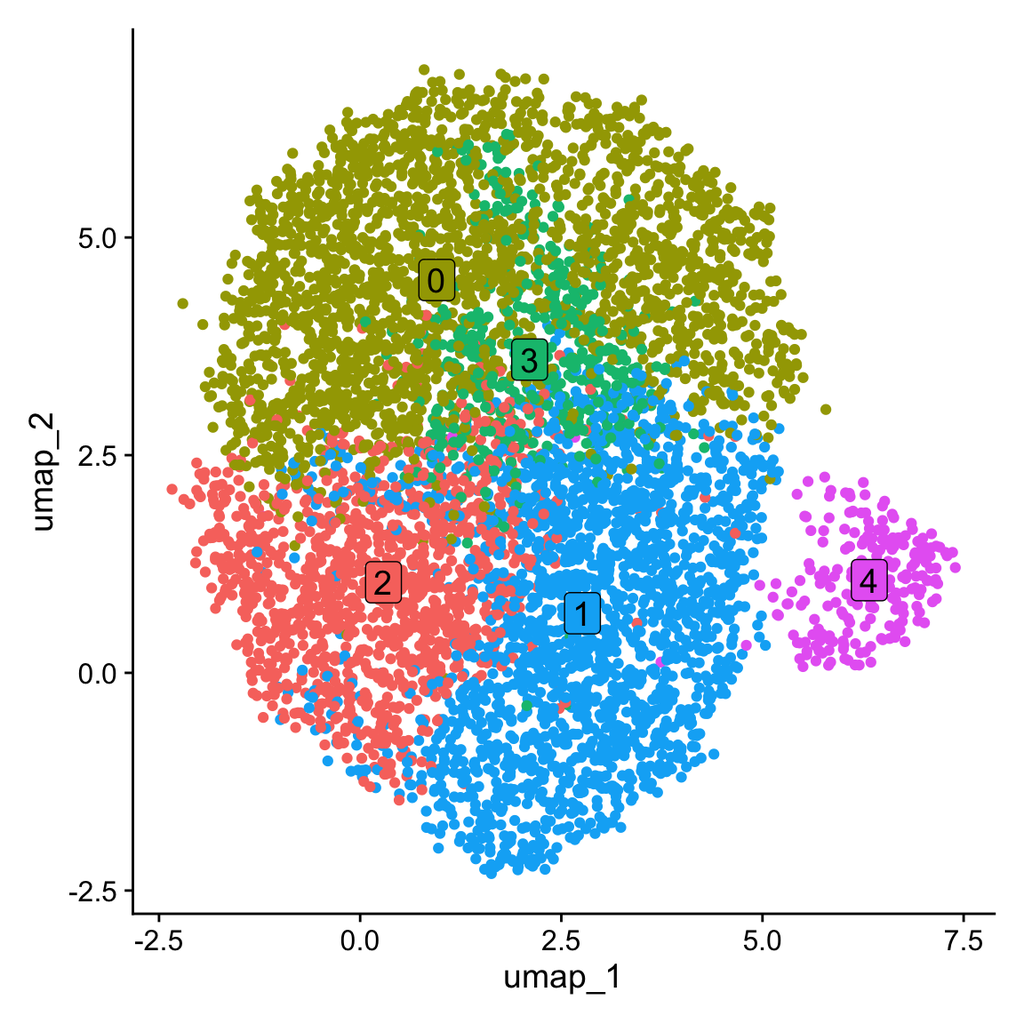

```r
Idents(MAIT) = 'seurat_cluster'
DimPlot(MAIT, reduction = "umap", pt.size = 1.5, label = T, label.size = 5, label.box = T) + NoLegend()
```

#### B cells

```r
B_P3 = readRDS("/Users/LabMavilio/Desktop/CDP_MAIT/B.RDS")
head(B_P3@meta.data)
```

```
##                               time patient_id seurat_cluster nCount_RNA
## AAACCTGAGTGAACAT-1-VCOV_01_P4   P3         01              2   3121.699
## AAACCTGGTCACTGGC-1-VCOV_01_P4   P3         01              5   3043.016
## AAACCTGGTGAAGGCT-1-VCOV_01_P4   P3         01              7   4143.168
## AAACCTGTCGACCAGC-1-VCOV_01_P4   P3         01              1   3222.438
## AAACGGGAGTGTACGG-1-VCOV_01_P4   P3         01              2   2710.005
## AAACGGGGTACCAGTT-1-VCOV_01_P4   P3         01              3   3777.686
##                               nFeature_RNA
## AAACCTGAGTGAACAT-1-VCOV_01_P4         1651
## AAACCTGGTCACTGGC-1-VCOV_01_P4         1557
## AAACCTGGTGAAGGCT-1-VCOV_01_P4         3118
## AAACCTGTCGACCAGC-1-VCOV_01_P4         1746
## AAACGGGAGTGTACGG-1-VCOV_01_P4         1276
## AAACGGGGTACCAGTT-1-VCOV_01_P4         2357
```

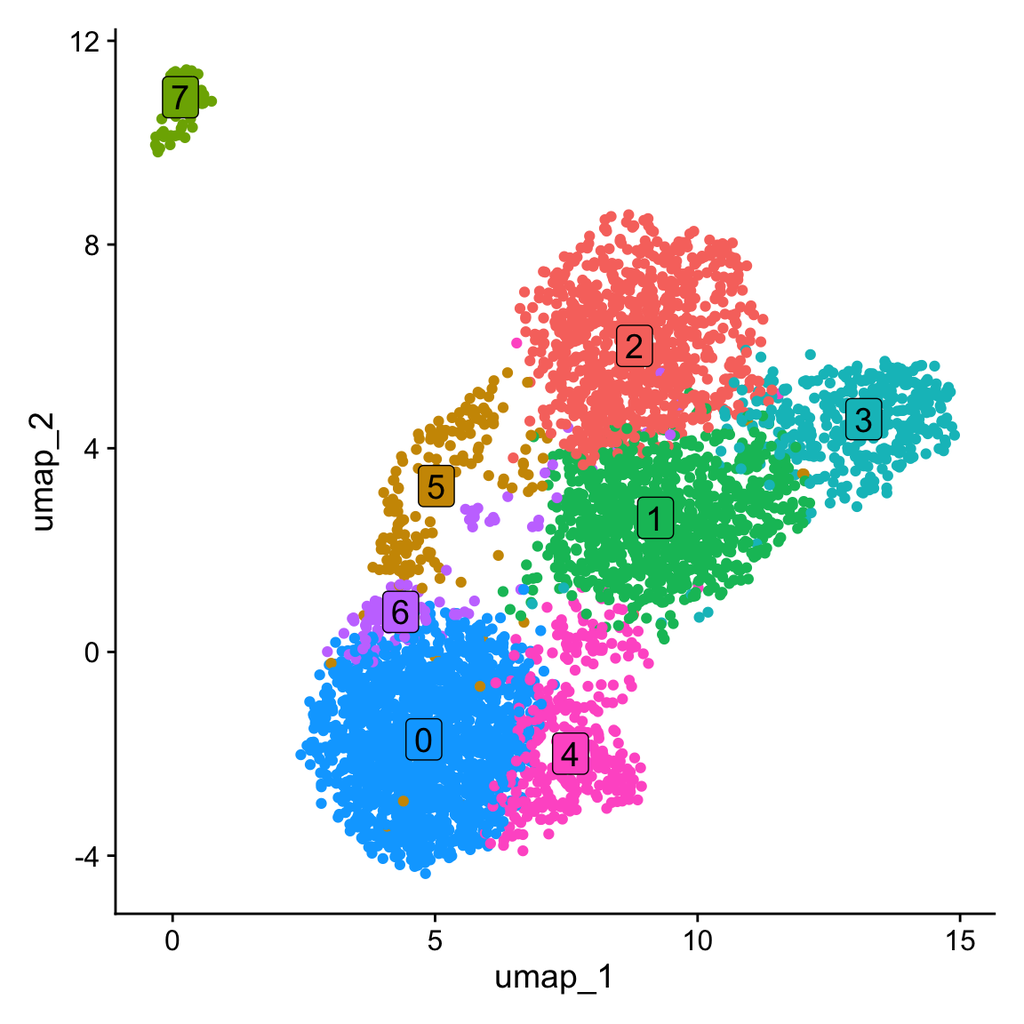

```r
Idents(B_P3) = 'seurat_cluster'
DimPlot(B_P3, reduction = "umap", pt.size = 1.5, label = T, label.size = 5, label.box = T) + NoLegend()
```

### Read in NicheNet’s *ligand-target prior model* and *ligand-receptor network*:

Ligand-receptor network: a set of potential ligands and receptors

```r
lr_network =  readRDS("/Users/LabMavilio/Desktop/CDP_MAIT/Nichenet/lr_network.rds")
head(lr_network)[1:2]
```

```
## # A tibble: 6 × 2
##   from  to
##   <chr> <chr>
## 1 CXCL1 CXCR2
## 2 CXCL2 CXCR2
## 3 CXCL3 CXCR2
## 4 CXCL5 CXCR2
## 5 PPBP  CXCR2
## 6 CXCL6 CXCR2
```

Ligand-target matrix: target genes in rows, ligands in columns

```r
ligand_target_matrix =  readRDS("/Users/LabMavilio/Desktop/CDP_MAIT/Nichenet/ligand_target_matrix.rds")
head(ligand_target_matrix)[1:5, 1:5]
```

```
##                 CXCL1        CXCL2        CXCL3        CXCL5         PPBP
## A1BG     3.534343e-04 4.041324e-04 3.729920e-04 3.080640e-04 2.628388e-04
## A1BG-AS1 1.650894e-04 1.509213e-04 1.583594e-04 1.317253e-04 1.231819e-04
## A1CF     5.787175e-04 4.596295e-04 3.895907e-04 3.293275e-04 3.211944e-04
## A2M      6.027058e-04 5.996617e-04 5.164365e-04 4.517236e-04 4.590521e-04
## A2M-AS1  8.898724e-05 8.243341e-05 7.484018e-05 4.912514e-05 5.120439e-05
```

# Perform NicheNet analysis

### Define the sender/receiver cell population and determine which genes are expressed in both populations

#### Sender: MAIT cells

```r
Idents(MAIT) = 'time'
expressed_genes_sender = get_expressed_genes("P3", MAIT, pct = 0.10)
expressed_genes_sender =  expressed_genes_sender %>% .[. %in% rownames(ligand_target_matrix)]
head(expressed_genes_sender)
```

```
## [1] "NOC2L"    "ISG15"    "SDF4"     "UBE2J2"   "INTS11"   "AURKAIP1"
```

#### Receiver: B cells

Since there are several B cell clusters, to study the ligand-target interactions, each cluster has to be considered singularly. In this tutorial, we will focus on cluster 2:

```r
B_P3_c2 = subset(B_P3, idents = '2')

Idents(B_P3_c2) = 'time'
expressed_genes_receiver =  get_expressed_genes("P3", B_P3_c2, pct = 0.10)
background_expressed_genes =  expressed_genes_receiver %>% .[. %in% rownames(ligand_target_matrix)]
head(background_expressed_genes)
```

```
## [1] "NOC2L"    "ISG15"    "SDF4"     "UBE2J2"   "INTS11"   "AURKAIP1"
```

### Define a gene set of interest

These are the genes in the “receiver/target” cell population that are differently expressed between the baseline (P0/pre-vaccine) and the condition of interest (P3/three days after the vaccine boost). We want to know whether these genes are potentially affected by the ligands expressed by the interacting cells (MAIT cells). Differentially expressed genes (DEGs) were computed by applying the Seurat Wilcoxon statistic test (*FindMarkers function*)

```r
DEG = read.xlsx("/Users/LabMavilio/Desktop/CDP_MAIT/DEGs Bc2_P3vsP0.xlsx", rowNames = TRUE, colNames = TRUE)
head(DEG)
```

```
##     names    scores logfoldchanges        pvals    pvals_adj pct_nz_group
## 0   CXCR4 12.027671      0.6200501 2.542319e-33 9.305141e-29    0.8600451
## 1  NFKBIA 11.276079      0.6309243 1.722535e-29 3.152326e-25    0.8792325
## 2    EIF1 11.113688      0.1602703 1.076207e-28 1.313009e-24    1.0000000
## 3    CD83 10.028595      1.0464295 1.141291e-23 1.044309e-19    0.6354402
## 4     UBC  9.342984      0.1693263 9.365634e-21 6.855831e-17    0.9920993
## 5 TSC22D3  9.234664      0.2012565 2.590985e-20 1.485144e-16    0.9559819
```

```r
length(DEG$names)
```

```
## [1] 36601
```

Only significant DEGs have to be considered in the analysis:

```r
DEG_filter = filter(DEG, pvals_adj <= 0.05 & abs(logfoldchanges) >= 0.25  & pct_nz_group > 0.1)
head(DEG_filter)
```

```
##     names    scores logfoldchanges        pvals    pvals_adj pct_nz_group
## 0   CXCR4 12.027671      0.6200501 2.542319e-33 9.305141e-29    0.8600451
## 1  NFKBIA 11.276079      0.6309243 1.722535e-29 3.152326e-25    0.8792325
## 3    CD83 10.028595      1.0464295 1.141291e-23 1.044309e-19    0.6354402
## 6     EZR  9.224820      0.2921316 2.840362e-20 1.485144e-16    0.9379233
## 7   RBM38  9.194302      1.1195512 3.774370e-20 1.726822e-16    0.5474041
## 8 HERPUD1  8.807719      0.7714933 1.277181e-18 5.194012e-15    0.6444695
```

```r
length(DEG_filter$names)
```

```
## [1] 116
```

```r
rownames(DEG_filter) = DEG_filter$names
geneset_oi = rownames(DEG_filter)
head(geneset_oi)
```

```
## [1] "CXCR4"   "NFKBIA"  "CD83"    "EZR"     "RBM38"   "HERPUD1"
```

```r
length(geneset_oi)
```

```
## [1] 116
```

Among the DEGs, we have to select only the once in the *ligand_target_matrix*

```r
geneset_oi = geneset_oi %>% .[. %in% rownames(ligand_target_matrix)]
```

### Define a gene set of potential ligands

These are ligands that are expressed by the sender cell population (MAIT cells) and bind a putative receptor expressed by the receiver population (B cells)

```r
ligands =  lr_network %>% pull(from) %>% unique()
receptors = lr_network %>% pull(to) %>% unique()

expressed_ligands = intersect(ligands, expressed_genes_sender)
expressed_receptors =  intersect(receptors, expressed_genes_receiver)

potential_ligands =  lr_network %>% filter(from %in% expressed_ligands & to %in% expressed_receptors) %>% pull(from) %>% unique()
head(potential_ligands)
```

```
## [1] "TNF"     "TNFSF14" "CD40LG"  "TGFB1"   "ICAM1"   "CD28"
```

## Perform NicheNet ligand activity analysis

### Rank the potential ligands based on the presence of their target genes in the gene set of interest

This Pearson correlation indicates the ability of each ligand to predict differential expressed genes P3 vs P0, and better predictive ligands are thus ranked higher.

```r
ligand_activities = predict_ligand_activities(geneset = geneset_oi, background_expressed_genes = background_expressed_genes, ligand_target_matrix = ligand_target_matrix, potential_ligands = potential_ligands)
ligand_activities = ligand_activities %>% arrange(-pearson) %>% mutate(rank = rank(desc(pearson)))
ligand_activities[1:20, ]
```

```
## # A tibble: 20 × 6
##    test_ligand auroc   aupr aupr_corrected pearson  rank
##    <chr>       <dbl>  <dbl>          <dbl>   <dbl> <dbl>
##  1 CD28        0.677 0.0926         0.0714  0.141      1
##  2 CD40LG      0.682 0.0751         0.0539  0.137      2
##  3 ICAM1       0.663 0.0891         0.0679  0.133      3
##  4 ANXA1       0.652 0.0824         0.0612  0.117      4
##  5 CCL4        0.675 0.0695         0.0482  0.116      5
##  6 NAMPT       0.651 0.0743         0.0531  0.114      6
##  7 PTPRC       0.671 0.0673         0.0460  0.114      7
##  8 CCL5        0.639 0.0694         0.0481  0.114      8
##  9 HMGB1       0.679 0.0626         0.0413  0.112      9
## 10 GMFB        0.659 0.0687         0.0475  0.111     10
## 11 PECAM1      0.656 0.0685         0.0473  0.108     11
## 12 ITGB2       0.646 0.0688         0.0476  0.107     12
## 13 ALOX5AP     0.662 0.0640         0.0428  0.106     13
## 14 PPBP        0.635 0.0688         0.0476  0.104     14
## 15 CD2         0.652 0.0595         0.0383  0.103     15
## 16 TNF         0.675 0.0563         0.0351  0.101     16
## 17 CALM1       0.644 0.0654         0.0442  0.101     17
## 18 ITGB7       0.633 0.0644         0.0432  0.0993    18
## 19 SEMA4D      0.630 0.0629         0.0416  0.0992    19
## 20 TNFSF14     0.662 0.0610         0.0398  0.0992    20
```

The ligand activity measures how well a ligand can predict the observed differentially expressed genes compared to the background of expressed genes. Since it is a predictive analysis, we will focus on the top 20 pearson-ranked ligands.

```r
best_upstream_ligands = ligand_activities %>% top_n(20, pearson) %>% arrange(-pearson) %>% pull(test_ligand) %>% unique()
list(best_upstream_ligands)
```

```
## [[1]]
##  [1] "CD28"    "CD40LG"  "ICAM1"   "ANXA1"   "CCL4"    "NAMPT"   "PTPRC"
##  [8] "CCL5"    "HMGB1"   "GMFB"    "PECAM1"  "ITGB2"   "ALOX5AP" "PPBP"
## [15] "CD2"     "TNF"     "CALM1"   "ITGB7"   "SEMA4D"  "TNFSF14"
```

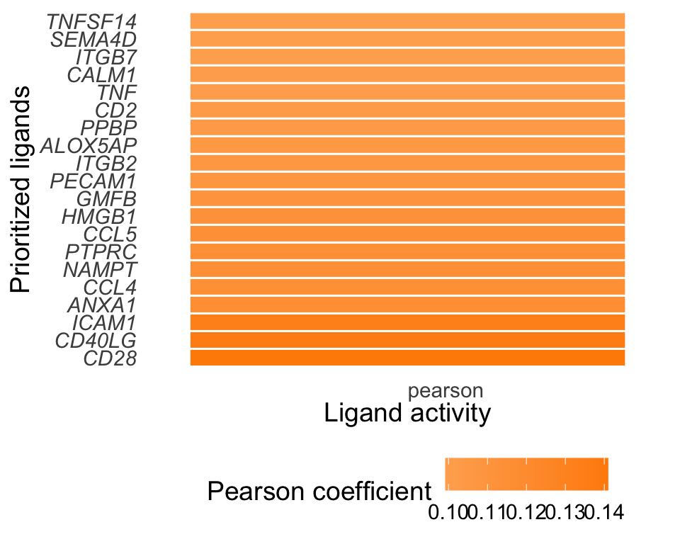

```r
ligand_pearson_matrix = ligand_activities %>% select(pearson) %>% as.matrix() %>% magrittr::set_rownames(ligand_activities$test_ligand)
vis_ligand_pearson = ligand_pearson_matrix[best_upstream_ligands, ] %>% as.matrix(ncol = 1) %>% magrittr::set_colnames("pearson")

vis_ligand_pearson %>%
  make_heatmap_ggplot("Prioritized ligands", "Ligand activity", color = "darkorange",
                      legend_position = "top", x_axis_position = "bottom", legend_title = "Pearson coefficient")  +
  theme(axis.text.y = element_text(face = "italic"), axis.text.x = element_text(angle = 0, vjust = 0, hjust = 0),
        legend.position = "bottom", legend.box = "horizontal") +
  theme(text = element_text(size = 14)) +
  scale_fill_gradient2(low = "whitesmoke",  high = "darkorange")
```

### Infer the top-predicted target genes of ligands that are top-ranked in the ligand activity analysis

```r
active_ligand_target_links_df = best_upstream_ligands %>% lapply(get_weighted_ligand_target_links, geneset = geneset_oi, ligand_target_matrix = ligand_target_matrix, n = 200) %>% bind_rows() %>% drop_na()
head(active_ligand_target_links_df)
```

```
## # A tibble: 6 × 3
##   ligand target   weight
##   <chr>  <chr>     <dbl>
## 1 CD28   BCL3    0.00162
## 2 CD28   ETS1    0.00148
## 3 CD28   FOS     0.00238
## 4 CD28   GADD45B 0.00158
## 5 CD28   IER2    0.00130
## 6 CD28   IRF1    0.00149
```

To visualize as a *heatmap matrix*:

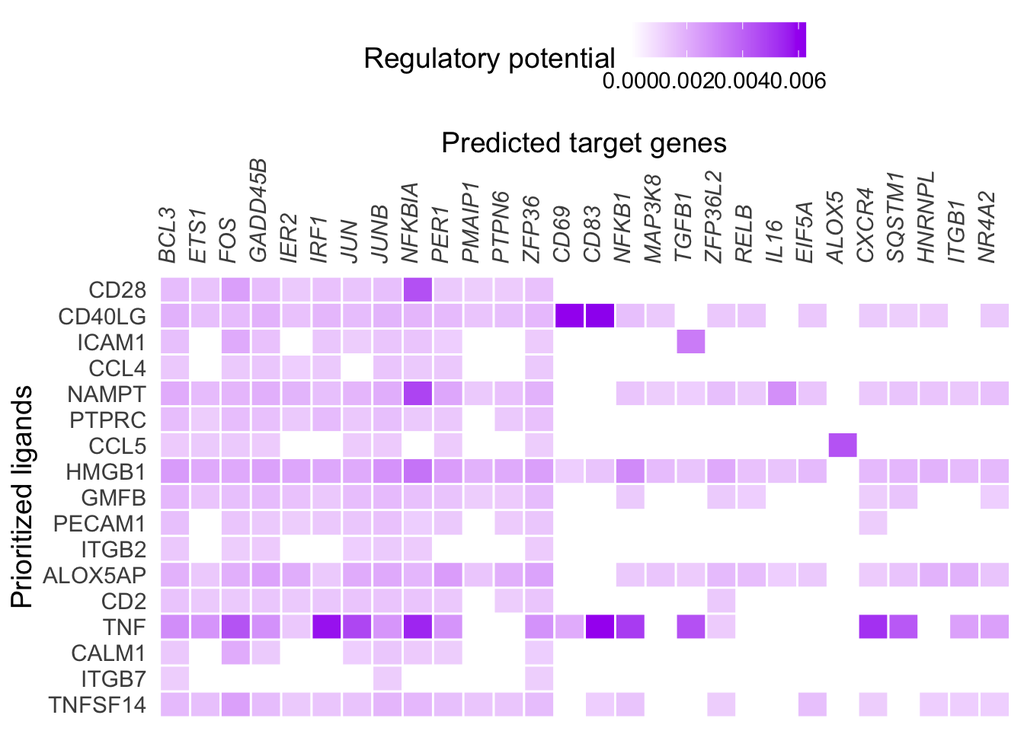

```r
active_ligand_target_links = prepare_ligand_target_visualization(ligand_target_df = active_ligand_target_links_df, ligand_target_matrix = ligand_target_matrix, cutoff = 0.33)

order_ligands = intersect(best_upstream_ligands, colnames(active_ligand_target_links)) %>% rev() %>% make.names()
order_targets = active_ligand_target_links_df$target %>% unique() %>% intersect(rownames(active_ligand_target_links)) %>% make.names()
rownames(active_ligand_target_links) = rownames(active_ligand_target_links) %>% make.names() # make.names() for heatmap visualization of genes like H2-T23
colnames(active_ligand_target_links) = colnames(active_ligand_target_links) %>% make.names() # make.names() for heatmap visualization of genes like H2-T23

vis_ligand_target = active_ligand_target_links[order_targets,order_ligands] %>% t()

vis_ligand_target %>%
  make_heatmap_ggplot("Prioritized ligands","Predicted target genes", color = "red",legend_position = "top",
                      x_axis_position = "top", legend_title = "Regulatory potential") +
  theme(axis.text.x = element_text(face = "italic")) + theme(text = element_text(size=14)) + scale_fill_gradient2(low = "whitesmoke",  high = "purple")
```

To visualize the data as a *chord diagram/circos plot*: To avoid making circos plots with too many ligand-target links, it’s possible to show only links with a weight higher than a predefined cutoff (e.g., links belonging to the 40% (quantile(0.4)) of lowest scores were removed)

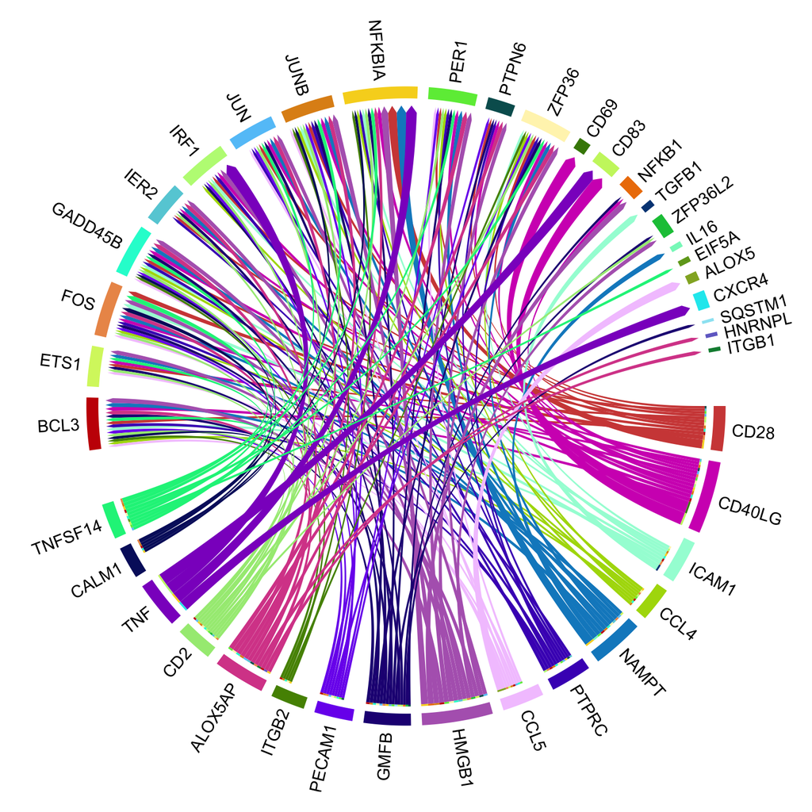

```r
cutoff_include_all_ligands = active_ligand_target_links_df$weight %>% quantile(0.4)
active_ligand_target_links_df_circos = active_ligand_target_links_df %>% filter(weight > cutoff_include_all_ligands)

ligands_to_remove = setdiff(active_ligand_target_links_df$ligand %>% unique(), active_ligand_target_links_df_circos$ligand %>% unique())
targets_to_remove = setdiff(active_ligand_target_links_df$target %>% unique(), active_ligand_target_links_df_circos$target %>% unique())

circos_links = active_ligand_target_links_df %>% filter(!target %in% targets_to_remove &!ligand %in% ligands_to_remove)

links_circle = circos_links %>% select(ligand, target, weight)
target_order = circos_links$target %>% unique()
ligand_order = circos_links$ligand %>% unique()
order = c(ligand_order, target_order)

circos.par(gap.after = c(rep(2, length(unique(links_circle[[1]]))-1), 10,
                         rep(2, length(unique(links_circle[[2]]))-1), 10))
chordDiagram(links_circle, directional = 1, order = order, link.sort = TRUE, link.decreasing = FALSE,
             transparency = 0, diffHeight = 0.005, direction.type = c("diffHeight", "arrows"),
             link.arr.type = "big.arrow", link.visible = links_circle$weight >= cutoff_include_all_ligands,annotationTrack = "grid",
             preAllocateTracks = list(track.height = 0.075))
circos.track(track.index = 1, panel.fun = function(x, y) {
  circos.text(CELL_META$xcenter, CELL_META$ylim[1], CELL_META$sector.index,
              facing = "clockwise", niceFacing = TRUE, adj = c(0, 0.55), cex = 1)
}, bg.border = NA) #
```